# Working with EIA Data

Gregory Vitz

2019-05-29

The United States Energy Information Administration (EIA) offers thousands of free data sets publicly, and they can all be found on their website [here](https://www.eia.gov/electricity/data/eia860/). I believe that each of the datasets can be downloaded as a CSV, however there is also an option to access the data through the EIA API. Today, I will be working with some data that I manually downloaded from the EIA website with generator level information. A future post may address how to use the EIA API to programatically get the data.

```r
library(tidyverse)
library(readxl)
library(here)
```

```r
file <- here("static", "data", "eia8602018er", "3_1_Generator_Y2018_Early_Release.xlsx")
plant_file <- here("static", "data", "eia8602018er", "2___Plant_Y2018_Early_Release.xlsx")


operable <- "Operable" %>%
    set_names() %>%
    read_excel(skip = 2, path = file, guess_max = 20000, n_max = 22050)

retired <- "Retired and Canceled" %>%
    set_names() %>%
    read_excel(skip = 2, path = file, guess_max = 4000, n_max = 4324)

plant <- "Plant" %>%
  set_names() %>%
  read_excel(skip = 2, path = plant_file, guess_max = 4000, n_max = 4324) %>%
  select(`Plant Code`, `Balancing Authority Code`)

glimpse(operable)
```

```
## Observations: 22,050
## Variables: 73
## $ `Utility ID`                                                              <dbl> ...
## $ `Utility Name`                                                            <chr> ...
## $ `Plant Code`                                                              <dbl> ...
## $ `Plant Name`                                                              <chr> ...
## $ State                                                                     <chr> ...
## $ County                                                                    <chr> ...
## $ `Generator ID`                                                            <chr> ...
## $ Technology                                                                <chr> ...
## $ `Prime Mover`                                                             <chr> ...
## $ `Unit Code`                                                               <chr> ...
## $ Ownership                                                                 <chr> ...
## $ `Duct Burners`                                                            <chr> ...
## $ `Can Bypass Heat Recovery Steam Generator?`                               <chr> ...
```

[output cut: 60 more lines]

As you can see there are a ton of variables in this data. Since we plan on doing an analysis of added and lost capacity we will only need a few.

```r
# Units that began operation in 2018
operable2018 <- operable %>%
    filter(`Operating Year` == 2018) %>%
    transmute(`Plant Code`,
              `Nameplate Capacity (MW)`,
              `Energy Source 1`,
              status = 1)

# Units that retired in 2018
retired2018 <- retired %>%
    filter(`Retirement Year` == 2018) %>%
    transmute(`Plant Code`,
              `Nameplate Capacity (MW)`,
              `Energy Source 1`,
              status = 0)

all_data <- bind_rows(operable2018, retired2018) %>%
    left_join(plant, by = "Plant Code") %>%
    rename(plant_code = `Plant Code`,
           nameplate = `Nameplate Capacity (MW)`,
           energy_source = `Energy Source 1`,
           ba = `Balancing Authority Code`)
```

Joining the plant capacity and fuel data with balancing authority information will give an idea of what regions were impacted most by additions and retirements. Some minor data manipulation is needed in order to create a stacked bar chart.

```r
all_data <- all_data %>%
    mutate(capacity = if_else(status == 1,
                              nameplate,
                              -nameplate))
```

Creating the first ggplot

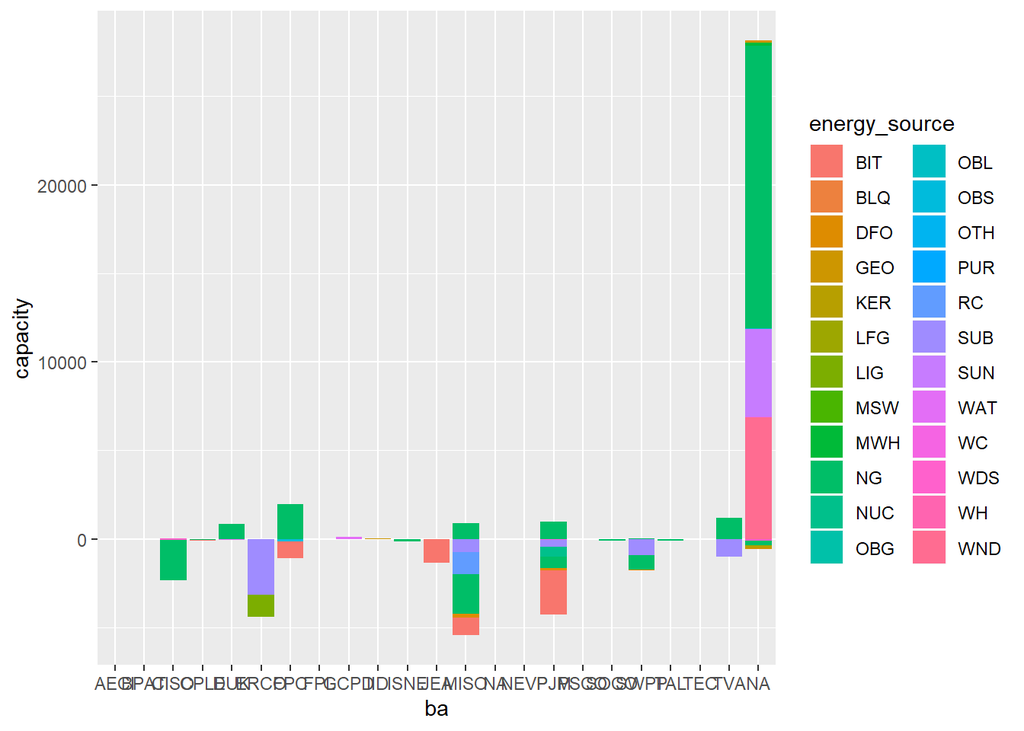

```r
all_data %>%
    ggplot(aes(ba, capacity, fill = energy_source)) +
    geom_bar(stat = "identity", position = "stack")
```

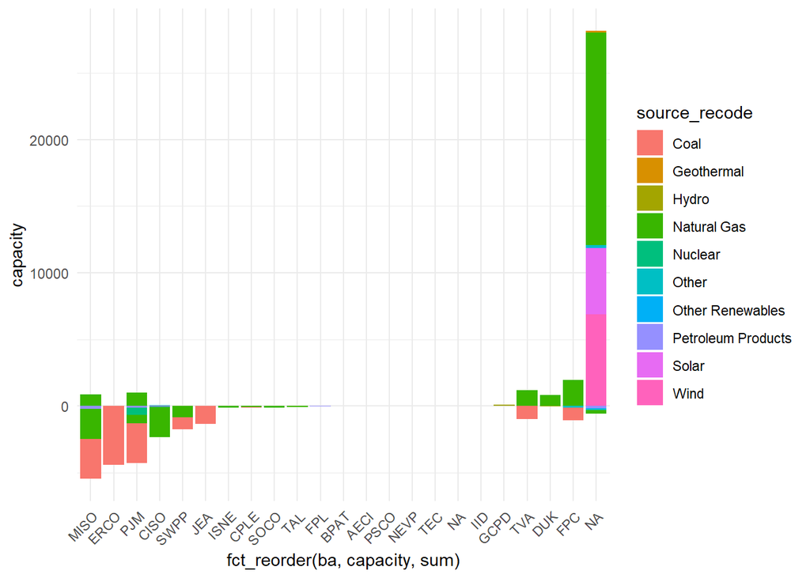

```r
theme_set(theme_minimal())

coal <- c("ANT", "BIT", "LIG", "SGC", "SUB", "WC", "RC")
petrol <- c("DFO", "JF", "KER", "PC", "PG", "RFO", "SGP", "WO")
other_gas <- c("BFG",  "OG")
other_renew <- c("OBL", "SLW", "BLQ", "WDL", "LFG", "OBG")


all_data2 <- all_data %>%
    mutate(source_recode = case_when(
        energy_source %in% coal ~ "Coal",
        energy_source %in% petrol ~ "Petroleum Products",
        energy_source %in% other_gas ~ "Other Gas",
        energy_source %in% other_renew ~ "Other Renewables",
        energy_source == "NG" ~ "Natural Gas",
        energy_source == "SUN" ~ "Solar",
        energy_source == "WND" ~ "Wind",
        energy_source == "GEO" ~ "Geothermal",
        energy_source == "WAT" ~ "Hydro",
        energy_source == "NUC" ~ "Nuclear",
        TRUE ~ "Other"
    ))

all_data2 %>%
    ggplot(aes(fct_reorder(ba, capacity, sum), capacity, fill = source_recode)) +
    geom_bar(stat = "identity", position = "stack") +
    theme(
        axis.text.x = element_text(angle = 45, hjust = 1)
    )
```

Lots of capacity was added in regions that we don’t have BA codes for. If we drop those areas, we will get a better idea of which Balancing areas had capacity additions/losses.

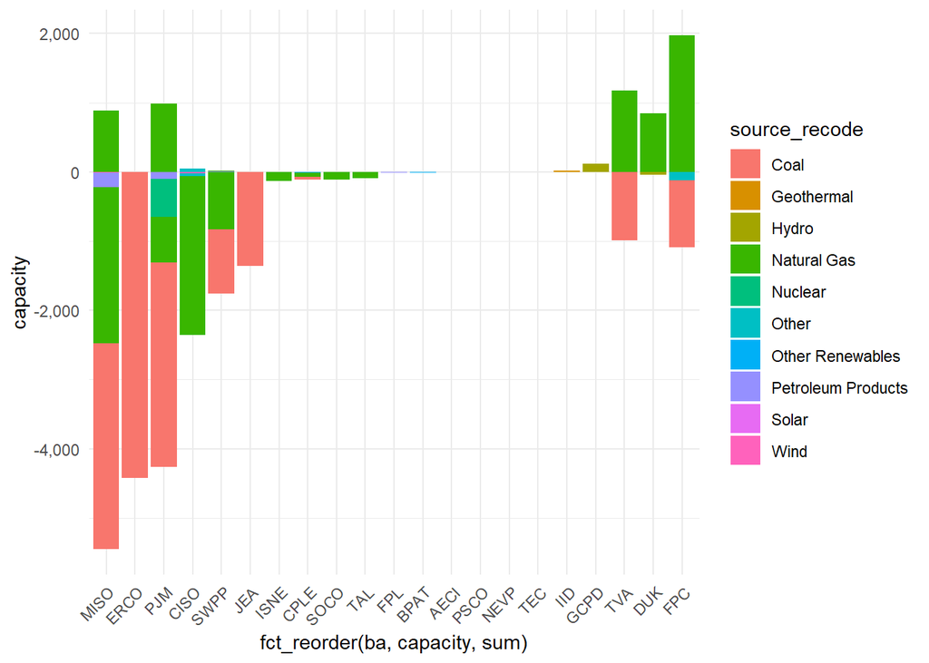

```r
all_data2 %>%
    filter(ba != "NA") %>%
    ggplot(aes(fct_reorder(ba, capacity, sum), capacity, fill = source_recode)) +
    geom_bar(stat = "identity", position = "stack") +
    theme(
        axis.text.x = element_text(angle = 45, hjust = 1)
    ) +
    scale_y_continuous(labels = scales::comma)
```